# Quantification of Correct Personal Activity Patterns

Ravi Shankar

Thursday, August 20, 2015

### Executive Summary

##### Following libraries were used: caret, e1071, and ggplot2. The following libraries were also used, especialy for the figures at the end: rattle, rpart.plot, and RGtk2.

### Method

```r
test <- read.csv("pml-testing.csv", header=TRUE)
train <- read.csv("pml-training.csv", header=TRUE)
dim(train); dim(test)
# remove NA columns
train.sub <- train[,colSums(is.na(train)) != nrow(train) ]
test.sub <- test[,colSums(is.na(test)) != nrow(test) ]
# check that number of columns left is the same
dim(train.sub); dim(test.sub)
# remove the "yes" rows
train.s <- train[train$new_window=="no",]
train.sub <- train.s[,colSums(is.na(train.s)) != nrow(train.s)]
dim(train.sub)
# remove columns with blank entries
train.sub2 <- train.sub[,colSums((train.sub=="")) != nrow(train.sub) ]
test.sub2 <- test.sub[,colSums( (test.sub=="")) != nrow(test.sub) ]
dim(train.sub2); dim(test.sub2)
# verify that the colnames are the same
names(train.sub2)== names(test.sub2)
names(train.sub2)[60]
names(test.sub2)[60]
# remove large redundant files
rm(test); rm(train)
rm(test.sub); rm(train.sub)
rm(train.s)
# now we have cleaned data sets - rename them
testing <- test.sub2
training <- train.sub2
rm(test.sub2); rm(train.sub2)
```

[output not shown]

```r
set.seed(32343)
InTrain <- createDataPartition(y=training$classe, p=0.8, list=FALSE)
train.set <- training[InTrain,]
valid.set <- training[-InTrain,]
dim(train.set); dim(valid.set)
```

```
## [1] 15375    60
```

```
## [1] 3841   60
```

```r
# remove time and date info from the sets
TrainData <- train.set[,-1:-6]
dim(TrainData)
```

```
## [1] 15375    54
```

```r
#M <- abs(cor(TrainData[,-54]))
#diag(M) <- 0
#which(M > 0.8,arr.ind=T)
ValidData <- valid.set[,-1:-6]
dim(ValidData)
```

```
## [1] 3841   54
```

```r
TestData <- testing[,-1:-6]
dim(TestData)
```

```
## [1] 20 54
```

```r
#remove unessential datasets
rm(testing); rm(train.set); rm(valid.set); rm(training)
```

##### It was decided to use principal component analysis to identify orthogonal intermediate variables and use them in the model fit. The threshold was set to 0.95 which picked the top 25 principal components (PCs). This reduced the complexity of the computation, while reducing the risk of overfitting. The choice of ‘pca’ in the preProcess method automatically scales and centers the individual variables so larger range variables do not influence the KNN clustering algorithm that was invoked in a later step. The predict method was then used to tranform the raw data variables of the training data to a new set of variables comprised of these PCs. The train method was then used to build a modelfit on this new data set for the KNN clustering method. The modelfit was evaluated on the ‘validation’ data (after it had been subject to the predict method to secure a dataset with 25 PCs). Resulting confusion matrix yielded an accuracy of 0.966, with the CI of (0.960, 0.972). Specificity and Sensitivity for all the five pattern classes were uniformly high, respectively at 0.99 and 0.94 (or above). See below for code and results.

```r
# Method 2: From Professor's Week 3, first lecture
table(TrainData$classe)
```

```
##
##    A    B    C    D    E
## 4377 2975 2682 2518 2823
```

```r
table(ValidData$classe)
```

```
##
##    A    B    C    D    E
## 1094  743  670  629  705
```

```r
table(TestData[54])
```

```
##
##  1  2  3  4  5  6  7  8  9 10 11 12 13 14 15 16 17 18 19 20
##  1  1  1  1  1  1  1  1  1  1  1  1  1  1  1  1  1  1  1  1
```

```r
#Preprocessing for PCA
preProc <- preProcess(TrainData[,-54],method="pca",thresh=0.95)
trainPC <- predict(preProc,TrainData[,-54])
modelFit <- train(TrainData$classe ~ .,method="knn",data=trainPC)
validPC <- predict(preProc,ValidData[,-54])
confusionMatrix(ValidData$classe,predict(modelFit,validPC))
```

```
## Confusion Matrix and Statistics
##
##           Reference
## Prediction    A    B    C    D    E
##          A 1079    7    4    3    1
##          B   20  698   16    4    5
##          C    7    6  645   12    0
##          D    5    0   18  604    2
##          E    1    8    6    5  685
##
## Overall Statistics
##
##                Accuracy : 0.9662
##                  95% CI : (0.9599, 0.9716)
##     No Information Rate : 0.2895
##     P-Value [Acc > NIR] : < 2.2e-16
##
##                   Kappa : 0.9572
##  Mcnemar's Test P-Value : 0.004803
##
## Statistics by Class:
##
##                      Class: A Class: B Class: C Class: D Class: E
## Sensitivity            0.9703   0.9708   0.9361   0.9618   0.9885
## Specificity            0.9945   0.9856   0.9921   0.9922   0.9936
## Pos Pred Value         0.9863   0.9394   0.9627   0.9603   0.9716
## Neg Pred Value         0.9880   0.9932   0.9861   0.9925   0.9974
## Prevalence             0.2895   0.1872   0.1794   0.1635   0.1804
## Detection Rate         0.2809   0.1817   0.1679   0.1573   0.1783
## Detection Prevalence   0.2848   0.1934   0.1744   0.1638   0.1835
## Balanced Accuracy      0.9824   0.9782   0.9641   0.9770   0.9911
```

##### The split was changed to 0.95 (for ‘training’) and 0.05 (for ‘validation’) and the process repeated. The computation took significantly longer (25 minutes vs 10 minutes) with marginal increase in accuracy (to 0.979). Specificity and sensitivity also improved slightly. This also verified that the model was a stable and repeatable model fit. Results for this are not shown.

```r
modFit <- train(TrainData$classe ~ .,method="rpart",data=trainPC)
print(modFit$finalModel)
```

```
## n= 15375
##
## node), split, n, loss, yval, (yprob)
##       * denotes terminal node
##
##  1) root 15375 10998 A (0.28 0.19 0.17 0.16 0.18)
##    2) PC8< 1.322368 12647  8583 A (0.32 0.18 0.2 0.11 0.19)
##      4) PC3>=-0.3349688 7728  4440 A (0.43 0.14 0.22 0.082 0.14) *
##      5) PC3< -0.3349688 4919  3612 E (0.16 0.23 0.18 0.17 0.27)
##       10) PC13< 0.2037622 3025  2026 B (0.16 0.33 0.2 0.16 0.15) *
##       11) PC13>=0.2037622 1894  1045 E (0.16 0.075 0.14 0.18 0.45) *
##    3) PC8>=1.322368 2728  1657 D (0.11 0.27 0.049 0.39 0.17) *
```

### Results:

##### The Testing data (‘TestData’) was then preprocessed with the predict method to obtain the data in terms of the 25 PCs and the predict method was invoked again to predict or estimate the unknown pattern codes. This was repeated with the model fits obtained with both the splits. Both yielded the same prediction values (‘value’). These were submitted at the Coursera site. The submission record showed that 19 of the 20 were predicted right, thus matching well the accuracy predicted above (of at least 0.96).

```r
testPC <- predict(preProc,TestData[,-54])
value <- predict(modelFit, testPC)
value
```

```
##  [1] B A A A A E D B A A B C B A E E A B B B
## Levels: A B C D E
```

### Reference:

##### Ugulino, W. et al. Wearable Computing: Accelerometers’ Data Classification of Body Postures and Movements. Proc. of 21st Brazilian Symposium on Artificial Intelligence. Advances in Artificial Intelligence - SBIA 2012. In: Lecture Notes in Computer Science. , pp. 52-61. Curitiba, PR: Springer Berlin / Heidelberg, 2012.

### Figures

##### Figure 1: The Classification Tree

[figure not shown]

##### Figure 2: Better Illustrated Classification Tree

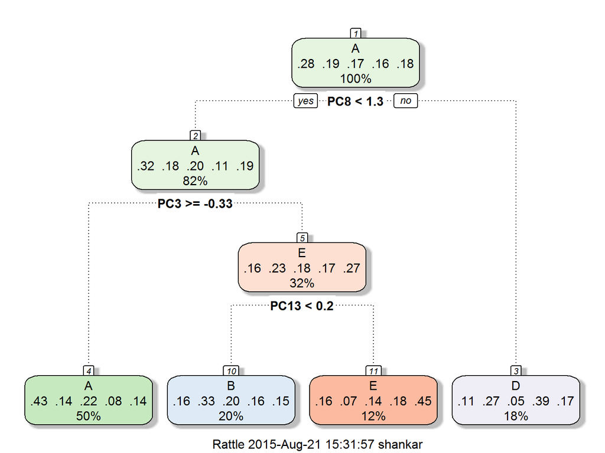